# Data Analysis and Lab.

Lab 6

Suhwan Bong

2023-10-17

## 1. Feature engineering

In this section, we will study methods to handle variables. Transforming variables to use in modeling is called `feature engineering`.

```r
data = read.csv('akc.csv')
```

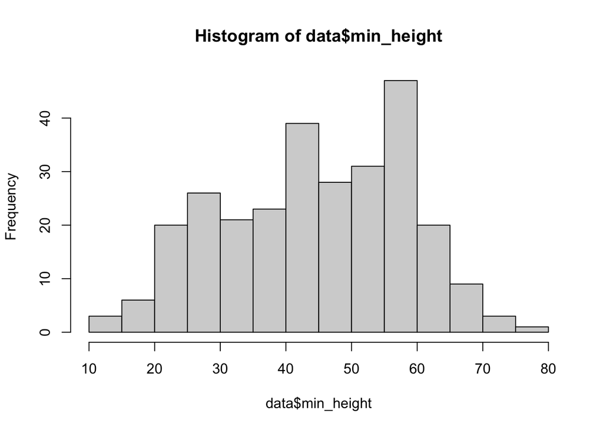

```r
hist(data$min_height)
```

- Nominal variables

```r
table(data$group)
```

```
##
## Foundation Stock Service            Herding Group              Hound Group
##                       68                       30                       32
##      Miscellaneous Class       Non-Sporting Group           Sporting Group
##                       11                       21                       32
##            Terrier Group                Toy Group            Working Group
##                       31                       21                       31
```

- Ordinal variables

```r
table(data$grooming_frequency_category)
```

```
##
##                           2-3 Times a Week Brushing            Daily Brushing
##                         7                        57                        18
##     Occasional Bath/Brush           Weekly Brushing
##                        76                       119
```

Usually it is easy to use numeric data as it is. However, sometimes we have to handle it.

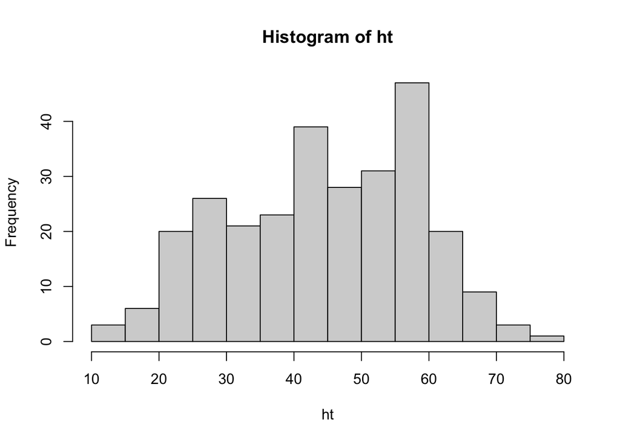

```r
ht = na.omit(data$min_height)
hist(ht)
```

First, we may use transformation such as log-transformation.

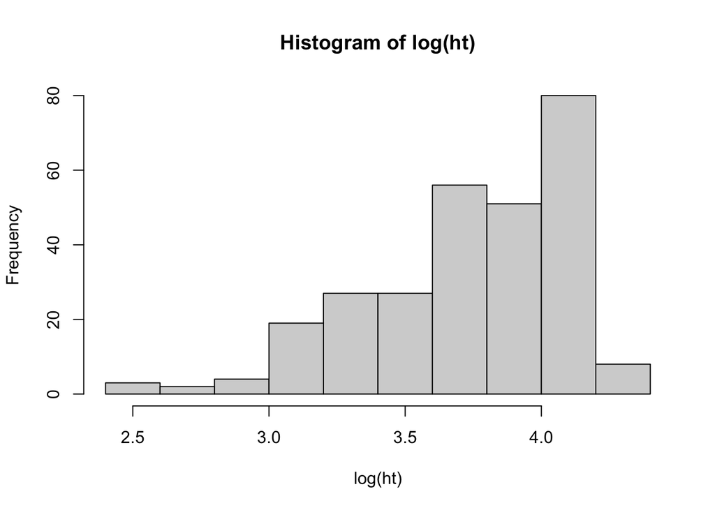

```r
hist(log(ht))
```

Second, we can make numerical variable into categorical variable.

```r
cut_ht = cut(ht, breaks = c(0,30,45,60,80))
table(cut_ht)
```

```
## cut_ht
##  (0,30] (30,45] (45,60] (60,80]
##      55      83     106      33
```

### Handling nominal variables

We have to make string variables into factor variables.

```r
typeof(data$group)
```

```
## [1] "character"
```

```r
typeof(factor(data$group))
```

```
## [1] "integer"
```

To deal with nominal variables, we usually use `one-hot encoding`.

```r
one_hot = model.matrix(~0+data$group)
head(one_hot)
```

```
##   data$groupFoundation Stock Service data$groupHerding Group
## 1                                  0                       0
## 2                                  0                       0
## 3                                  0                       0
## 4                                  0                       0
## 5                                  0                       0
## 6                                  1                       0
##   data$groupHound Group data$groupMiscellaneous Class
## 1                     0                             0
## 2                     1                             0
## 3                     0                             0
## 4                     0                             0
## 5                     0                             0
## 6                     0                             0
##   data$groupNon-Sporting Group data$groupSporting Group data$groupTerrier Group
## 1                            0                        0                       0
## 2                            0                        0                       0
## 3                            0                        0                       1
## 4                            0                        0                       0
## 5                            0                        0                       0
## 6                            0                        0                       0
##   data$groupToy Group data$groupWorking Group
## 1                   1                       0
## 2                   0                       0
## 3                   0                       0
## 4                   0                       1
## 5                   0                       1
## 6                   0                       0
```

### Handling ordinal variables

Similarly, we have to make to factor variable.

```r
typeof(data$grooming_frequency_category)
```

```
## [1] "character"
```

```r
typeof(factor(data$grooming_frequency_category,
              levels = c("Occasional Bath/Brush", "Weekly Brushing",
                         "2-3 Times a Week Brushing", "Daily Brushing")))
```

```
## [1] "integer"
```

Or we may match some numeric values to ordinal variables.

### Handling missing values

There is NA value in shedding column.

```r
shedding = data$shedding_value
is.na(c(1,2,3,NA))
```

```
## [1] FALSE FALSE FALSE  TRUE
```

```r
sum(is.na(shedding))
```

```
## [1] 20
```

```r
length(shedding)
```

```
## [1] 277
```

First, we may remove values with NA.

```r
shedding1 = na.omit(shedding)
sum(is.na(shedding1))
```

```
## [1] 0
```

```r
length(shedding1)
```

```
## [1] 257
```

Second, we may replace NA with mean value.

```r
shedding2 = shedding
shedding2[is.na(shedding)] = mean(shedding, na.rm=TRUE)
sum(is.na(shedding2))
```

```
## [1] 0
```

```r
length(shedding2)
```

```
## [1] 277
```

## 2. Simple Linear Regression

A simple linear regression model for an outcome $y$ as a function of a predictor $x$ takes the form of
$$y_i = \beta_0 + \beta_1 x_i + \varepsilon_i, \text{ for } i = 1,2,\dots,
n.$$

We will fit `min_weight` on `min_height`.

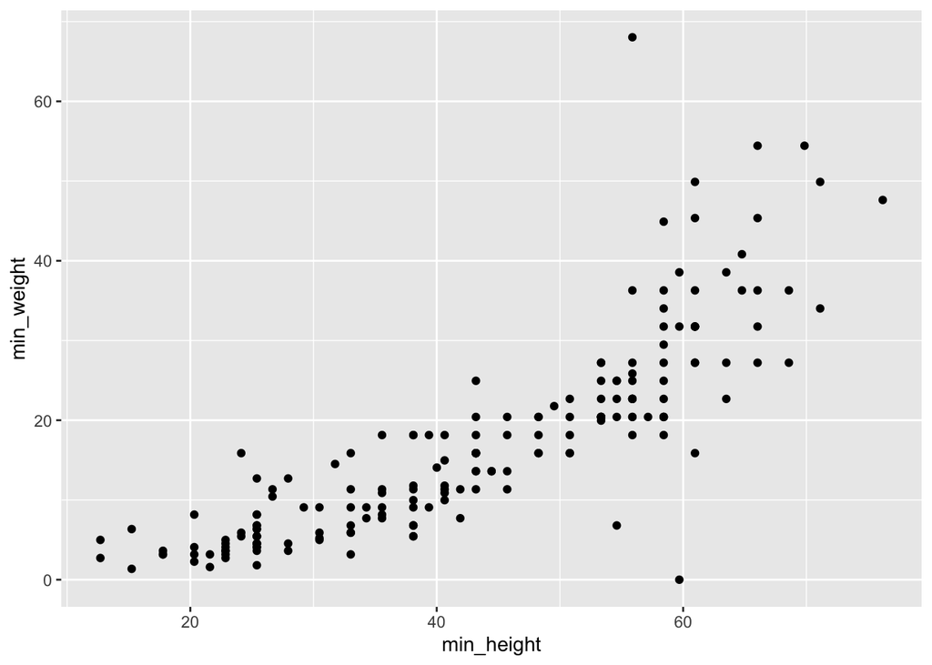

```r
data = data[complete.cases(data),]
data %>%
  ggplot(aes(x = min_height, y = min_weight)) +
  geom_point()
```

It seems to have a positive correlation. Then, a simple linear model can summarize the scatterplot? How can we find the best fitted line?

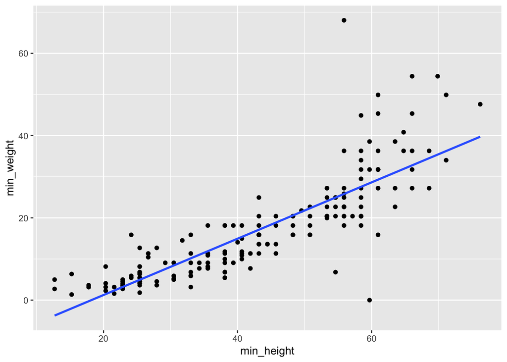

```r
data %>%
  ggplot(aes(x = min_height, y = min_weight)) +
  geom_point() +
  geom_smooth(method = "lm", se = F)
```

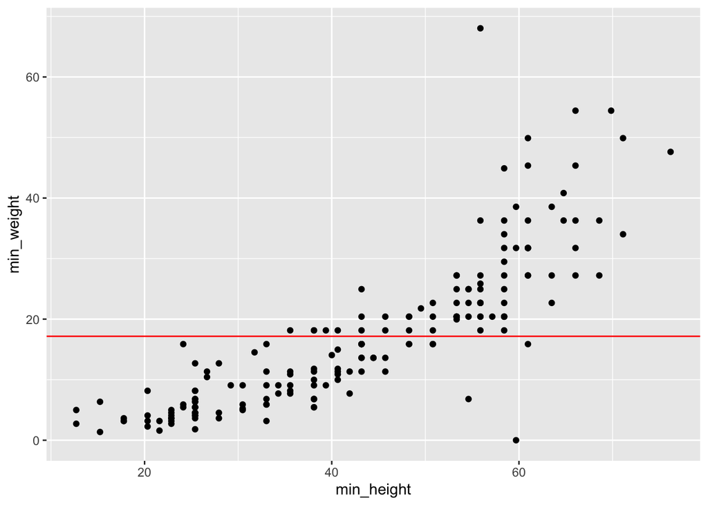

```r
data %>%
  ggplot(aes(x = min_height, y = min_weight)) +
  geom_point() +
  geom_hline(yintercept = mean(data$min_weight), col = "red")
```

The `lm()` function finds the best coefficients $\hat\beta_0$ and $\hat\beta_1$ where the fitted values are given by $\hat y_i = \hat\beta_0 + \hat\beta_1 x_i$. What is left over is captured by the residuals $\hat\varepsilon_i = y_i - \hat y_i$. The model almost never fits perfectly.

```r
mod <- lm(min_weight ~ min_height, data)
summary(mod)
```

```
##
## Call:
## lm(formula = min_weight ~ min_height, data = data)
##
## Residuals:
##     Min      1Q  Median      3Q     Max
## -28.422  -3.662  -0.729   2.579  42.226
##
## Coefficients:
##              Estimate Std. Error t value Pr(>|t|)
## (Intercept) -12.45037    1.53295  -8.122 6.46e-14 ***
## min_height    0.68474    0.03346  20.463  < 2e-16 ***
## ---
## Signif. codes:  0 '***' 0.001 '**' 0.01 '*' 0.05 '.' 0.1 ' ' 1
##
## Residual standard error: 6.88 on 184 degrees of freedom
## Multiple R-squared:  0.6947, Adjusted R-squared:  0.6931
## F-statistic: 418.7 on 1 and 184 DF,  p-value: < 2.2e-16
```

Also, it can be used with `predict()`.

```r
# using the same data
data.frame(data$min_height, data$min_weight, mod$fitted.values)[1:3,]
```

```
##   data.min_height data.min_weight mod.fitted.values
## 1           22.86        3.175147          3.202888
## 2           63.50       22.679619         31.030910
## 3           58.42       22.679619         27.552407
```

```r
predict(mod)[1:3]
```

```
##         1         2         3
##  3.202888 31.030910 27.552407
```

```r
# using the new data
newdata <- data.frame(min_height = 5 * (4:8))
newdata$prediction <- predict(mod, newdata)
newdata
```

```
##   min_height prediction
## 1         20   1.244518
## 2         25   4.668241
## 3         30   8.091965
## 4         35  11.515688
## 5         40  14.939411
```

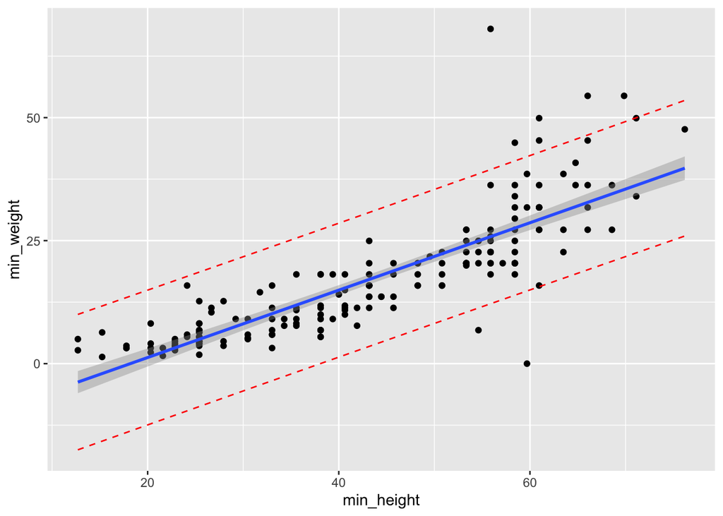

```r
data2 <- data %>%
  mutate(
    lower.pi = predict(mod, interval = "prediction")[,2],
    upper.pi = predict(mod, interval = "prediction")[,3])

ggplot(data2, aes(x = min_height, y = min_weight)) +
  geom_point() +
  geom_smooth(method = "lm", se = TRUE) + # 95% Conf.Int.
  geom_line(aes(y=lower.pi), color = "red", linetype ="dashed") +
  geom_line(aes(y=upper.pi), color = "red", linetype ="dashed")
```

## 3. Loss Functions

We need some metric of how good or bad our predictions are. A loss function characterizes the cost, error, or fit resulting from a particular choice of model or model parameters. The loss function looks like $L(y, \hat y)$. Two popular choices are $L1$ loss and $L2$ loss.

1. $L2$ loss : $L(y, \hat y) = (y - \hat y)^2$
2. $L1$ loss : $L(y, \hat y) = \vert y - \hat y \vert$

As we discussed in lecture class, we use Gongcha Sales example. Question: How many drinks do you expect to sell tomorrow?

```r
gongcha <- c(200, 210, 220, 290, 330)

# sample mean
mean(gongcha)
```

```
## [1] 250
```

```r
# sample median
median(gongcha)
```

```
## [1] 220
```

Consider an SLR model, $\hat y = \beta_0 + \beta_1 x$. To measure the total loss across all data points, a natural measure is of the average loss across all points.
$$\hat R(\theta) = \hat R(\beta_0, \beta_1) = \frac{1}{n} \sum_i L(y_i,
\hat y_i)$$

1. For $L2$ loss, $\text{MSE} = \frac{1}{n} \sum_{i = 1}^n (y_i - \hat y_i)^2$
2. For $L1$ loss, $\text{MAE} = \frac{1}{n} \sum_{i = 1}^n \vert y_i - \hat y_i \vert$

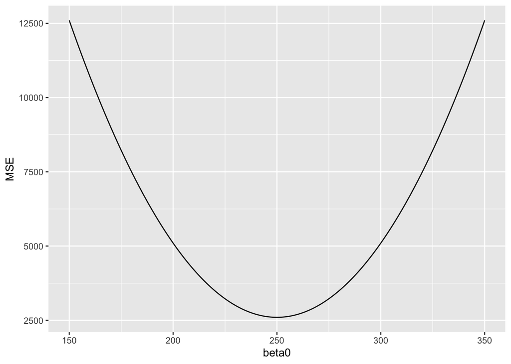

```r
mse <- function(y, est){
  mean((y-est)**2)
}

mae <- function(y, est){
  mean(abs(y-est))
}

est.seq <- 150:350
mse.seq <- sapply(est.seq, mse, y = gongcha)
mae.seq <- sapply(est.seq, mae, y = gongcha)

data.frame(beta0 = est.seq, MSE = mse.seq, MAE = mae.seq) %>%
  ggplot(aes(x = beta0, y = MSE)) +
  geom_line()
```

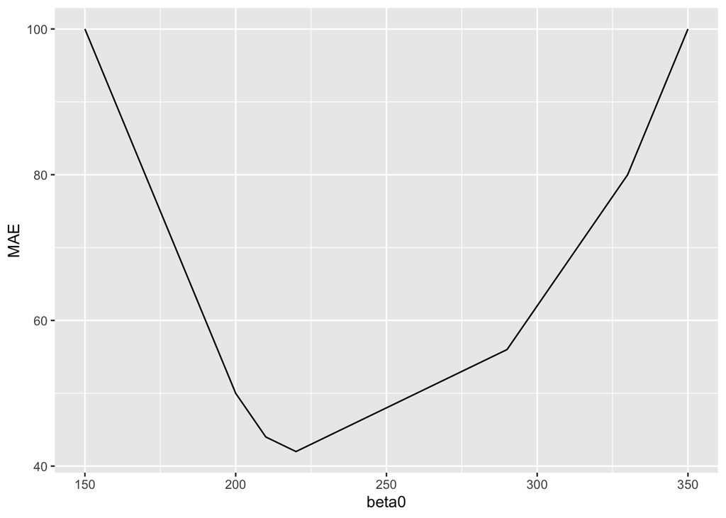

```r
data.frame(beta0 = est.seq, MSE = mse.seq, MAE = mae.seq) %>%
  ggplot(aes(x = beta0, y = MAE)) +
  geom_line()
```

Since MSE is smoother than MAE, it is easy to minimize.

## 4. Multiple Linear Regression & Model selection

Multiple regression is a natural extension of simple linear regression that incorporates multiple explanatory (or predictor) variables. It has the general form:
$$y = \beta_0 +\beta_1 x_1 +\dots +\beta_p x_p + \varepsilon$$

For example,

```r
data1 = data[,c("popularity","min_height","min_weight",
                "grooming_frequency_value","energy_level_value","trainability_value")]

head(data1)
```

```
##   popularity min_height min_weight grooming_frequency_value energy_level_value
## 1        148      22.86   3.175147                      0.6                0.6
## 2        113      63.50  22.679619                      0.8                0.8
## 3         60      58.42  22.679619                      0.6                0.6
## 4         47      60.96  31.751466                      0.8                0.8
## 5         58      58.42  34.019428                      0.6                0.8
## 7        175      58.42  20.411657                      0.2                0.8
##   trainability_value
## 1                0.8
## 2                0.2
## 3                1.0
## 4                1.0
## 5                0.4
## 7                0.6
```

Suppose that we want to estimate the `popularity` using `min_height`, `min_weight`, `grooming_frequency_value`, `energy_level_value`, and `trainability_value`. We will perform linear regression using all variables.

```r
library(broom)
model = lm(popularity~., data = data1)
tidy(model)
```

```
## # A tibble: 6 × 5
##   term                     estimate std.error statistic     p.value
##   <chr>                       <dbl>     <dbl>     <dbl>       <dbl>
## 1 (Intercept)               128.       24.7       5.19  0.000000553
## 2 min_height                  0.656     0.519     1.26  0.208
## 3 min_weight                 -0.975     0.611    -1.60  0.112
## 4 grooming_frequency_value  -36.6      19.8      -1.85  0.0665
## 5 energy_level_value         15.9      27.7       0.573 0.568
## 6 trainability_value        -62.1      17.2      -3.62  0.000388
```

```r
confint(model)
```

```
##                                2.5 %     97.5 %
## (Intercept)               79.4175797 176.732476
## min_height                -0.3693092   1.680641
## min_weight                -2.1819677   0.231156
## grooming_frequency_value -75.7393578   2.513455
## energy_level_value       -38.8561209  70.636045
## trainability_value       -96.0068609 -28.219333
```

Among various variable selections in multiple regression, we will use AIC to choose the best model. We have to select proper variables.

```r
library(olsrr)
```

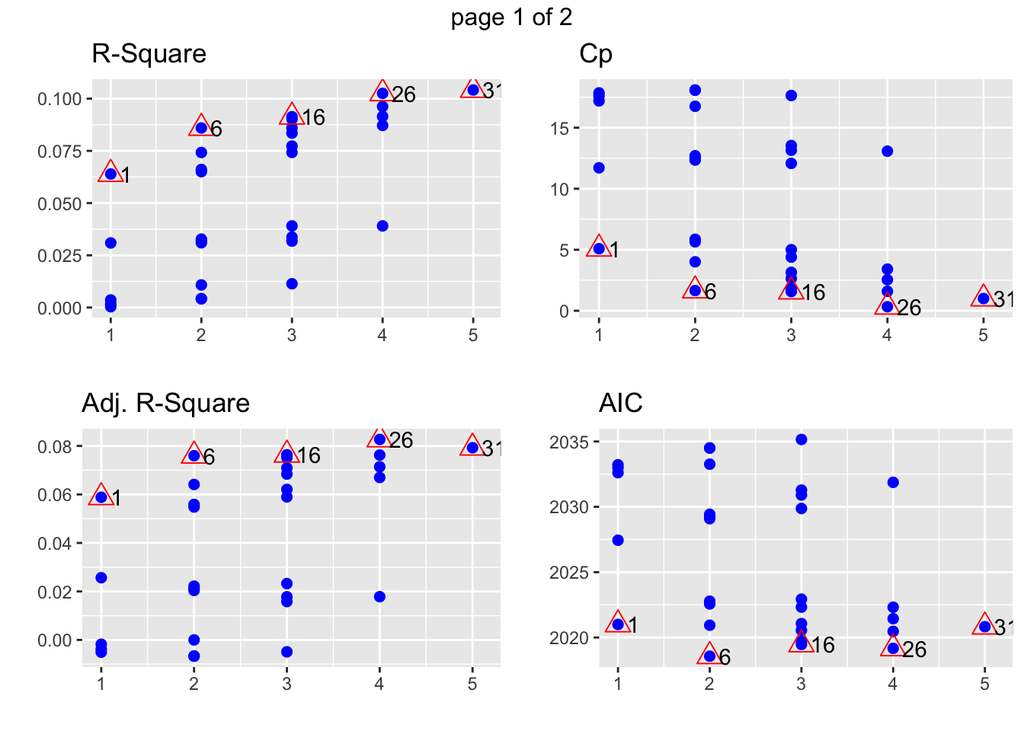

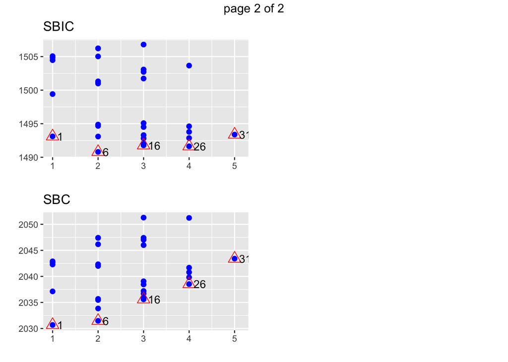

```r
k = ols_step_all_possible(model)
plot(k)
```

```r
head(k)
```

```
##    Index N                                  Predictors     R-Square
## 5      1 1                          trainability_value 0.0639192006
## 3      2 1                    grooming_frequency_value 0.0309144366
## 4      3 1                          energy_level_value 0.0036228486
## 1      4 1                                  min_height 0.0016415426
## 2      5 1                                  min_weight 0.0003664344
## 14     6 2 grooming_frequency_value trainability_value 0.0859603439
##    Adj. R-Square Mallow's Cp
## 5    0.058831805    6.083552
## 3    0.025647667   12.715088
## 4   -0.001792245   18.198694
## 1   -0.003784319   18.596792
## 2   -0.005066357   18.852995
## 14   0.075970839    3.654900
```

However, computing all possible cases requires heavy computation.

### Forward selection

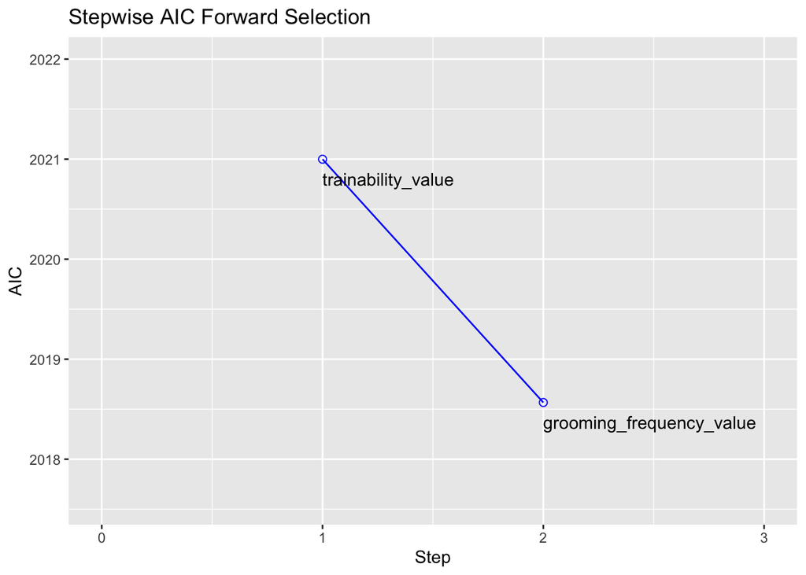

```r
forw = ols_step_forward_aic(model)
plot(forw)
```

```r
forw
```

```
##
##                                    Selection Summary
## ---------------------------------------------------------------------------------------
## Variable                      AIC        Sum Sq         RSS         R-Sq      Adj. R-Sq
## ---------------------------------------------------------------------------------------
## trainability_value          2020.999    37688.695    551941.563    0.06392      0.05883
## grooming_frequency_value    2018.567    50684.820    538945.438    0.08596      0.07597
## ---------------------------------------------------------------------------------------
```

### Backward selection

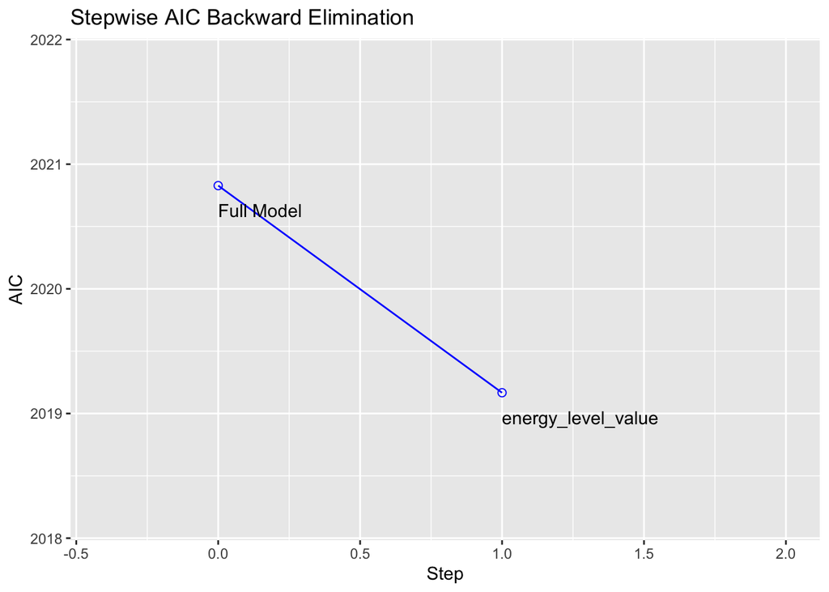

```r
back = ols_step_backward_aic(model)
plot(back)
```

```r
back
```

```
##
##
##                            Backward Elimination Summary
## ---------------------------------------------------------------------------------
## Variable                AIC          RSS         Sum Sq       R-Sq      Adj. R-Sq
## ---------------------------------------------------------------------------------
## Full Model            2020.828    528219.933    61410.325    0.10415      0.07927
## energy_level_value    2019.167    529182.515    60447.743    0.10252      0.08268
## ---------------------------------------------------------------------------------
```

### Regression diagnostics

Basic assumptions of multiple linear regression - Linearity - Homoscedasticity - Normality - Independence

#### Linearity

We can use residual plot or perform lack of fit test.

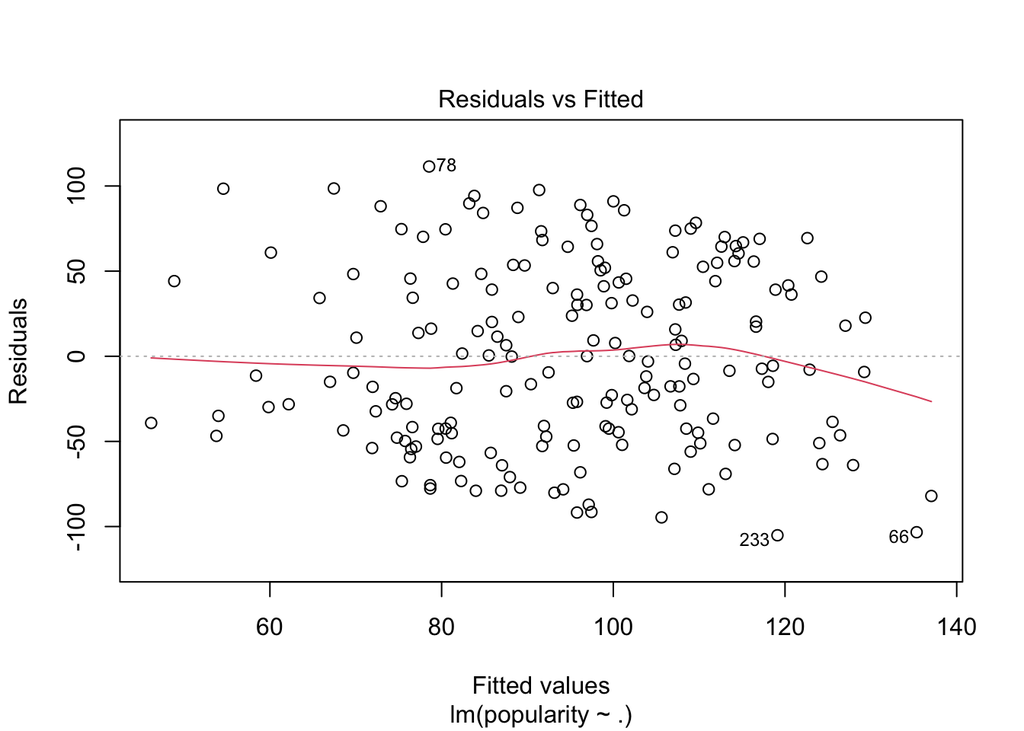

```r
plot(model, which=1)
```

Lack of fit test

```r
summary(model)
```

```
##
## Call:
## lm(formula = popularity ~ ., data = data1)
##
## Residuals:
##      Min       1Q   Median       3Q      Max
## -105.119  -44.808   -6.448   45.169  111.454
##
## Coefficients:
##                          Estimate Std. Error t value Pr(>|t|)
## (Intercept)              128.0750    24.6588   5.194 5.53e-07 ***
## min_height                 0.6557     0.5194   1.262 0.208490
## min_weight                -0.9754     0.6115  -1.595 0.112423
## grooming_frequency_value -36.6130    19.8286  -1.846 0.066466 .
## energy_level_value        15.8900    27.7444   0.573 0.567544
## trainability_value       -62.1131    17.1768  -3.616 0.000388 ***
## ---
## Signif. codes:  0 '***' 0.001 '**' 0.01 '*' 0.05 '.' 0.1 ' ' 1
##
## Residual standard error: 54.17 on 180 degrees of freedom
## Multiple R-squared:  0.1042, Adjusted R-squared:  0.07927
## F-statistic: 4.185 on 5 and 180 DF,  p-value: 0.001272
```

#### Homoscedasticity

We can use residual plot. If the variance seems different, we have to use transformation.

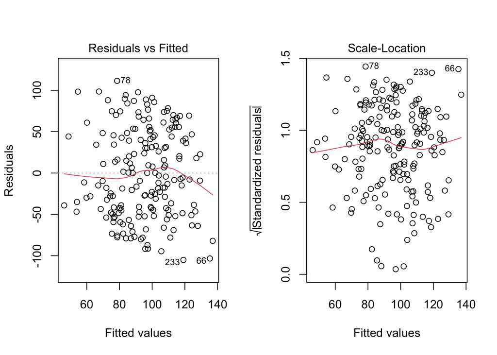

```r
par(mfrow=c(1,2))
plot(model, which=c(1,3))
```

#### Normality

We can use Q-Q plot. If the normality does not assumed, we have to use transformation.

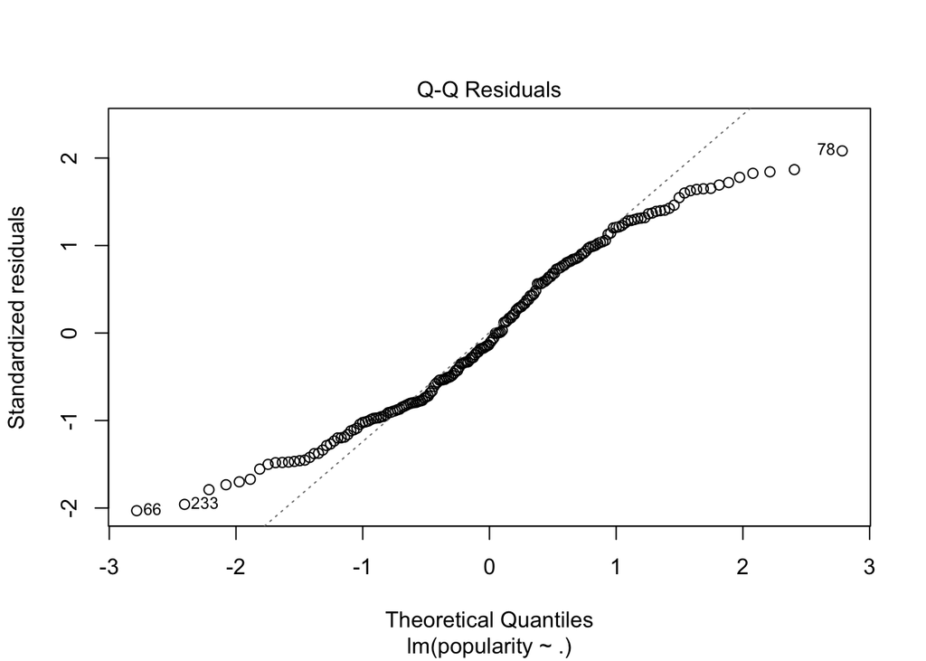

```r
plot(model, which=2)
```

#### Independence

We can perform Durbin-Watson test to check independence.

```r
library(lmtest)
dwtest(popularity ~ min_height + min_weight + grooming_frequency_value + energy_level_value + trainability_value, data=data, alternative="two.sided")
```

```
##
##  Durbin-Watson test
##
## data:  popularity ~ min_height + min_weight + grooming_frequency_value +     energy_level_value + trainability_value
## DW = 1.9712, p-value = 0.8507
## alternative hypothesis: true autocorrelation is not 0
```

## 5. Other Considerations in Regression

```r
data$energetic_yn <- data$energy_level_category == "Energetic"
table(data$energetic_yn)
```

```
##
## FALSE  TRUE
##   124    62
```

```r
data1 = data[,c("popularity","min_weight", "energetic_yn")]
head(data1)
```

```
##   popularity min_weight energetic_yn
## 1        148   3.175147        FALSE
## 2        113  22.679619         TRUE
## 3         60  22.679619        FALSE
## 4         47  31.751466         TRUE
## 5         58  34.019428         TRUE
## 7        175  20.411657         TRUE
```

Since `energetic_yn` is a categorical variable, we need other approach.

### Parallel Slope

```r
model1 <- lm(popularity ~ min_weight + energetic_yn, data = data1)
summary(model1)
```

```
##
## Call:
## lm(formula = popularity ~ min_weight + energetic_yn, data = data1)
##
## Residuals:
##     Min      1Q  Median      3Q     Max
## -97.180 -49.149   0.282  50.634 100.296
##
## Coefficients:
##                  Estimate Std. Error t value Pr(>|t|)
## (Intercept)      93.19107    7.63213  12.210   <2e-16 ***
## min_weight       -0.09364    0.33471  -0.280    0.780
## energetic_ynTRUE 10.54059    8.79419   1.199    0.232
## ---
## Signif. codes:  0 '***' 0.001 '**' 0.01 '*' 0.05 '.' 0.1 ' ' 1
##
## Residual standard error: 56.53 on 183 degrees of freedom
## Multiple R-squared:  0.008153,   Adjusted R-squared:  -0.002687
## F-statistic: 0.7521 on 2 and 183 DF,  p-value: 0.4728
```

### Interaction Terms

```r
model2 <- lm(popularity ~ min_weight * energetic_yn, data = data1)
summary(model2)
```

```
##
## Call:
## lm(formula = popularity ~ min_weight * energetic_yn, data = data1)
##
## Residuals:
##      Min       1Q   Median       3Q      Max
## -104.389  -48.280   -2.396   48.502  100.528
##
## Coefficients:
##                             Estimate Std. Error t value Pr(>|t|)
## (Intercept)                  89.7445     8.2913  10.824   <2e-16 ***
## min_weight                    0.1088     0.3851   0.283    0.778
## energetic_ynTRUE             24.8734    16.1090   1.544    0.124
## min_weight:energetic_ynTRUE  -0.8259     0.7779  -1.062    0.290
## ---
## Signif. codes:  0 '***' 0.001 '**' 0.01 '*' 0.05 '.' 0.1 ' ' 1
##
## Residual standard error: 56.51 on 182 degrees of freedom
## Multiple R-squared:  0.01426,    Adjusted R-squared:  -0.00199
## F-statistic: 0.8776 on 3 and 182 DF,  p-value: 0.4538
```

### Non-linear Relationships

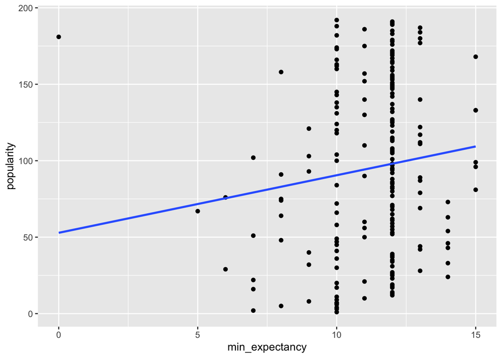

```r
ggplot(data, aes(x = min_expectancy, y = popularity)) +
  geom_point() +
  geom_smooth(method = lm, se = F)
```

Consider the second order and third order terms of `min_expectancy`.

```r
nonlin <- lm(popularity ~ min_expectancy + I(min_expectancy^2) + I(min_expectancy^3), data = data)
summary(nonlin)
```

```
##
## Call:
## lm(formula = popularity ~ min_expectancy + I(min_expectancy^2) +
##     I(min_expectancy^3), data = data)
##
## Residuals:
##     Min      1Q  Median      3Q     Max
## -91.457 -45.828   1.844  45.882 104.597
##
## Coefficients:
##                      Estimate Std. Error t value Pr(>|t|)
## (Intercept)         178.85411   54.08092   3.307  0.00114 **
## min_expectancy      -56.32058   19.44936  -2.896  0.00425 **
## I(min_expectancy^2)   7.45632    2.44892   3.045  0.00267 **
## I(min_expectancy^3)  -0.27388    0.09552  -2.867  0.00463 **
## ---
## Signif. codes:  0 '***' 0.001 '**' 0.01 '*' 0.05 '.' 0.1 ' ' 1
##
## Residual standard error: 54.98 on 182 degrees of freedom
## Multiple R-squared:  0.06686,    Adjusted R-squared:  0.05148
## F-statistic: 4.347 on 3 and 182 DF,  p-value: 0.005514
```

There are a lot more smoothing techniques to study non-linear relationships.

## 6. Exercises

In the `HELP` (Health Evaluation and Linkage to Primary Care) study, investigators were interested in determining predictors of severe depressive symptoms (measured by the Center for Epidemiologic Studies—Depression scale, `cesd`) amongst a cohort enrolled at a substance abuse treatment facility.

```r
library(mdsr)
HELPrct
```

1. Select 10 variables to predict `cesd` and explain why you choose those variables.
2. Handle various values and NAs before we start analysis.
3. Perform multiple linear regression and explain the result.
4. Perform stepwise selection methods to find the best model and justify your result.
5. Use the model in 4, perform regression diagnostic procedures (linearity, homoscedasticity, normality, independence). Explain the result for each assumption. If the assumption does not hold, give an alternative method to satisfy the result.
6. Select only 2 variables that were the most significant in 3. Compare two models, (1) multiple linear regression not considering the interaction term and (2) multiple linear regression considering the interaction term. Discuss the result.
7. Select only 1 variable that were the most significant in 3. To fit the multiple regression $y = \beta_0 + \beta_1 x+ \varepsilon$ using the $L1$ loss function, choose a proper grid range of $(\beta_0, \beta_1)$ and find the values of $\beta_0, \beta_1$ minimizing the total $L1$ loss.